# Reproducible Researh - Assigment 1

## Juan Guillermo López Guzmán

In this document we are working a database based on anonymous users data. You can download the database in this url: [database](https://d396qusza40orc.cloudfront.net/repdata%2Fdata%2Factivity.zip)

This is a briefly summary of database

```r
        summary(db)
```

```
##      steps                date          interval
##  Min.   :  0.00   2012-10-01:  288   Min.   :   0.0
##  1st Qu.:  0.00   2012-10-02:  288   1st Qu.: 588.8
##  Median :  0.00   2012-10-03:  288   Median :1177.5
##  Mean   : 37.38   2012-10-04:  288   Mean   :1177.5
##  3rd Qu.: 12.00   2012-10-05:  288   3rd Qu.:1766.2
##  Max.   :806.00   2012-10-06:  288   Max.   :2355.0
##  NA's   :2304     (Other)   :15840
```

Firstly we will get the total steps in each day for that we will use summarize function from the dplyr library

```r
        library(dplyr)
        summarize(group_by(db,date),sum=sum(db$steps))
```

[output not shown]

[output cut: 49 more lines]

To analize the distribution of the total steps in days we will make an histogram:

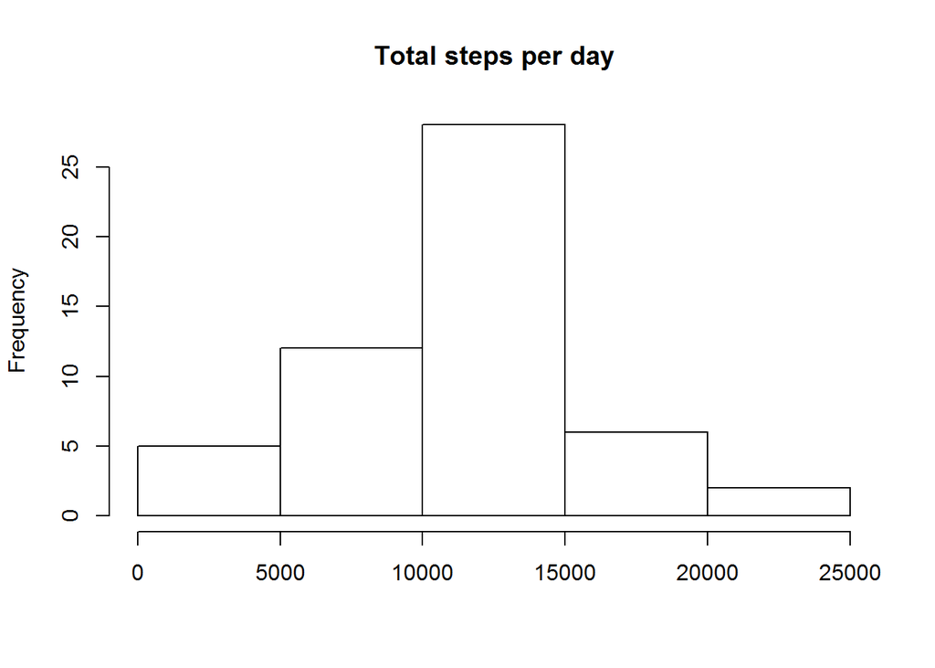

## What is the average daily activity pattern?

A time series plot will show the pattern across the day:

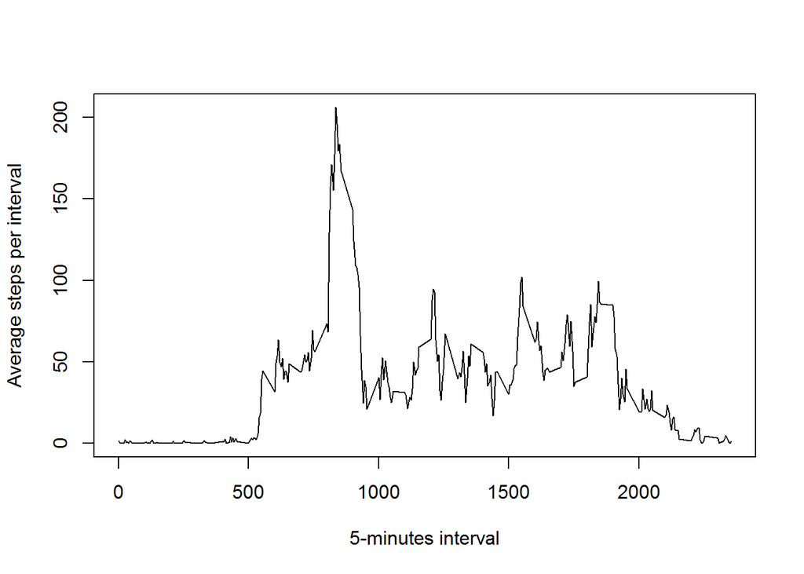

Now we need calculate the 5-minutes intervale with the maximum number of steps average. Firstly identify the maximum number after that we find the interval who contained that average:

```r
        max_steps<-max(plotdb$steps)
        filter<-plotdb$steps==max_steps
        max_interval<-plotdb$interval[filter]
```

So now we know the maximum number of average steps is 206.1698113 in the 835 5-minutes interval